# Case Study on Bike Share

Hyesun Kang

2023-09-21

# How do casual riders and annual members use bike-share program differently?

This case study was as a capstone project for my Google Data Analytics certificate.

Cyclistic is a fictitious bike-share company in Chicago. It features more than 5,800 bicycles and 600 docking stations. Cyclistic has been offering many pricing plans: *single-ride passes*, *full-day passes*, and *annual memberships*. Customers who purchase single-ride or full-day passes are referred to as **casual riders**, whereas customers who purchase annual memberships are referred to as **members**.

Since its launch in 2016, Cyclistic’s main marketing strategy has been building general awareness and appealing to broad consumer segments by offering flexible plans. The marketing team now wants to focus more on converting casual riders to annual riders, as it has found out annual members are much more profitable than casual riders. To maximize the number of annual members, Cyclistic’s marketing team wants to know **how annual members and casual riders use Cyclistic bikes differently**. Once different riding patterns by both types of riders are discovered, the marketing team can discuss **what could motivate casual riders to switch to annual membership** and **how social media could be used to influence casual riders to become a member.**

To answer the question of **how annual members and casual riders use Cyclistic bikes differently**, I have analyzed the history of all Cyclistic bike rides that happened in the year 2019. I have chosen the year 2019 specifically because I wanted to see the riding patterns *prior to* COVID-19. As things are now going back to normal (as of September 2021), I thought **pre-pandemic data**, rather than pandemic data (year 2020 to 2022), would be more relevant for future application.

The data has been made available by Motivate International Inc. under [this license](https://divvybikes.com/data-license-agreement) and is available for download [here](https://divvy-tripdata.s3.amazonaws.com/index.html).

## 1. Set up

### Install and load required packages

First, I’ll load **tidyverse** for data import and wrangling, **lubridate** for wrangling date attributes, **ggplot2** and **scales** for visualization, **dplyr** for data manipulation, and **skimr** for data summary.

```r
library(tidyverse)
library(lubridate)
library(ggplot2)
library(scales)
library(dplyr)
library(skimr)
```

### Import Data

I’ve uploaded Divvy Trips 2019 data sets into RStudio.

```r
q1_2019 <- read_csv("Divvy_Trips_2019_Q1.csv")
q2_2019 <- read_csv("Divvy_Trips_2019_Q2.csv")
q3_2019 <- read_csv("Divvy_Trips_2019_Q3.csv")
q4_2019 <- read_csv("Divvy_Trips_2019_Q4.csv")
```

## 2. Wrangle Data and Combine into a Single File

First, I compare data structure and column names each of the files

```r
str(q1_2019)
str(q2_2019)
str(q3_2019)
str(q4_2019)
```

With **str** function, I discovered that column names of **q2_2019** don’t match with the equivalent columns in the other three data frames.  
So, I renamed these columns.

```r
q2_2019 <- rename(q2_2019
                   ,trip_id = "01 - Rental Details Rental ID"
                   ,start_time = "01 - Rental Details Local Start Time"
                   ,end_time = "01 - Rental Details Local End Time"
                   ,bikeid = "01 - Rental Details Bike ID"
                   ,tripduration = "01 - Rental Details Duration In Seconds Uncapped"
                   ,from_station_name = "03 - Rental Start Station Name"
                   ,from_station_id = "03 - Rental Start Station ID"
                   ,to_station_name = "02 - Rental End Station Name"
                   ,to_station_id = "02 - Rental End Station ID"
                   ,usertype = "User Type"
                   ,gender = "Member Gender"
                   ,birthyear = "05 - Member Details Member Birthday Year")
```

Now that column names are identical across data frames, I could stack individual quarter’s data into one big data frame, **all_trips.**

```r
all_trips <- bind_rows(q1_2019, q2_2019, q3_2019, q4_2019)
```

## 3. Data Cleaning

*skim_without_chart* function (from skimr package) is useful when inspecting data frames. I look for inconsistencies in data such as data types, missing values, outliers, and so on.

```r
skim_without_charts(all_trips)
```

Data summary

| Name | all_trips |
| --- | --- |
| Number of rows | 3818004 |
| Number of columns | 12 |
| _______________________ |  |
| Column type frequency: |  |
| character | 4 |
| numeric | 6 |
| POSIXct | 2 |
| ________________________ |  |
| Group variables | None |

**Variable type: character**

| skim_variable | n_missing | complete_rate | min | max | empty | n_unique | whitespace |
| --- | --- | --- | --- | --- | --- | --- | --- |
| from_station_name | 0 | 1.00 | 10 | 43 | 0 | 640 | 0 |
| to_station_name | 0 | 1.00 | 10 | 43 | 0 | 641 | 0 |
| usertype | 0 | 1.00 | 8 | 10 | 0 | 2 | 0 |
| gender | 559206 | 0.85 | 4 | 6 | 0 | 2 | 0 |

**Variable type: numeric**

| skim_variable | n_missing | complete_rate | mean | sd | p0 | p25 | p50 | p75 | p100 |
| --- | --- | --- | --- | --- | --- | --- | --- | --- | --- |
| trip_id | 0 | 1.00 | 23915629.06 | 1212666.72 | 21742443 | 22873787 | 23962320 | 24963703 | 25962904 |
| bikeid | 0 | 1.00 | 3380.25 | 1902.51 | 1 | 1727 | 3451 | 5046 | 6946 |
| tripduration | 0 | 1.00 | 1450.20 | 29854.14 | 61 | 411 | 709 | 1283 | 10628400 |
| from_station_id | 0 | 1.00 | 201.67 | 156.08 | 1 | 77 | 174 | 289 | 673 |
| to_station_id | 0 | 1.00 | 202.64 | 156.24 | 1 | 77 | 174 | 291 | 673 |
| birthyear | 538751 | 0.86 | 1984.07 | 10.87 | 1759 | 1979 | 1987 | 1992 | 2014 |

**Variable type: POSIXct**

| skim_variable | n_missing | complete_rate | min | max | median | n_unique |
| --- | --- | --- | --- | --- | --- | --- |
| start_time | 0 | 1 | 2019-01-01 00:04:37 | 2019-12-31 23:57:17 | 2019-07-25 17:50:54 | 3306090 |
| end_time | 0 | 1 | 2019-01-01 00:11:07 | 2020-01-21 13:54:35 | 2019-07-25 18:12:23 | 3238342 |

I couldn’t find any data field description provided by Motivate International Inc., so I’ve created my own data field description of all_trips.

| Field | Data Type | Description |
| --- | --- | --- |
| from_station_name | character | name of station where the trip started |
| to_station_name | character | name of station where the trip ended |
| usertype | character | type of the user (‘Customer’ or ‘Subscriber’) |
| gender | character | gender of the rider |
| trip_id | numeric | trip ID |
| bikeid | numeric | bike ID |
| tripduration | numeric | length of the trip in seconds |
| from_station_id | numeric | station ID of where the trip started from |
| to_station_id | numeric | station ID of where the trip ended |
| birthyear | numeric | birth year of the rider |
| start_time | datetime | date and time when the trip started |
| end_time | datetime | date and time when the trip ended |

**Things to clean:**

1. Out of total 3,818,004 rows, **gender** and **birthyear** 559,206 and 538,751 rows with missing values, respectfully. I will still use these rows for analysis that is irrelevant to gender or age, but I will clean these out when we do analysis using these factors. Therefore, I will create two different filtered versions of this data frame, one with gender and age information and one without. However, before we do that, I will do some basic cleaning.
2. **trip_id**, **bikeid**, **from_station_id**, and **to_station_id** are numbers. These are supposed to be strings. So, I change their data type.

```r
all_trips <-  mutate(all_trips, trip_id = as.character(trip_id)
                              , bikeid = as.character(bikeid)
                              , from_station_id = as.character(from_station_id)
                              , to_station_id = as.character(to_station_id))
```

checking to make sure they have changed correctly.

```r
str(all_trips)
```

```
## tibble [3,818,004 × 12] (S3: tbl_df/tbl/data.frame)
##  $ trip_id          : chr [1:3818004] "21742443" "21742444" "21742445" "21742446" ...
##  $ start_time       : POSIXct[1:3818004], format: "2019-01-01 00:04:37" "2019-01-01 00:08:13" ...
##  $ end_time         : POSIXct[1:3818004], format: "2019-01-01 00:11:07" "2019-01-01 00:15:34" ...
##  $ bikeid           : chr [1:3818004] "2167" "4386" "1524" "252" ...
##  $ tripduration     : num [1:3818004] 390 441 829 1783 364 ...
##  $ from_station_id  : chr [1:3818004] "199" "44" "15" "123" ...
##  $ from_station_name: chr [1:3818004] "Wabash Ave & Grand Ave" "State St & Randolph St" "Racine Ave & 18th St" "California Ave & Milwaukee Ave" ...
##  $ to_station_id    : chr [1:3818004] "84" "624" "644" "176" ...
##  $ to_station_name  : chr [1:3818004] "Milwaukee Ave & Grand Ave" "Dearborn St & Van Buren St (*)" "Western Ave & Fillmore St (*)" "Clark St & Elm St" ...
##  $ usertype         : chr [1:3818004] "Subscriber" "Subscriber" "Subscriber" "Subscriber" ...
##  $ gender           : chr [1:3818004] "Male" "Female" "Female" "Male" ...
##  $ birthyear        : num [1:3818004] 1989 1990 1994 1993 1994 ...
```

3. **usertype** has “Customer” and “Subscriber” as shown below, which are equivalent to **casual user** and **annual member**, respectively.

```r
table(all_trips$usertype)
```

```
##
##   Customer Subscriber
##     880637    2937367
```

So, I change “Customer” to **casual** and “Subscriber” to **member.**

```r
all_trips <-  all_trips %>%
  mutate(usertype = recode(usertype, "Subscriber" = "member","Customer" = "casual"))
```

Check to make sure the proper number of observations were reassigned.

```r
table(all_trips$usertype)
```

```
##
##  casual  member
##  880637 2937367
```

4. **tripduration** is currently in seconds. So, I convert it to minutes to make it more readable.

```r
all_trips$tripduration <- round(all_trips$tripduration/60, digits=0)
```

Also, I rename that column to **tripduration_mm** to make it more clear of its unit.

```r
all_trips <- rename(all_trips, tripduration_mm = tripduration)
```

5. To analyze data by month, day of week, and hour, we need to add columns that list the **date**, **year**, **month**, **day**, **day of week**, and **time of day**.

```r
all_trips$date <- as.Date(all_trips$start_time)
all_trips$year <- format(as.Date(all_trips$date), "%Y")
all_trips$month <- format(as.Date(all_trips$date), "%m")
all_trips$day <- format(as.Date(all_trips$date), "%d")
all_trips$day_of_week <- format(as.Date(all_trips$date), "%a")
all_trips$time_of_day_hour <- format(as.POSIXct(all_trips$start_time), format = "%H")
```

6. Station names and station IDs have some incongruencies.
- number of unique values for **from_station_id** and **from_station_name** are different (616 vs 640)
- number of unique values for **to_station_id** and **to_station_name** are also different (617 vs 641)
- Also, why there is one more **to_station_name** than **from_station_name**? (640 vs 641)

I will probably not find any meaningful conclusion from focusing on stations because data on distance or location is not available. So, I will just ignore this incongruency, and if I ever need to use station field, I will just use station IDs rather than names.

7. There seems to be some bad data or outliers in **tripduration_mm** and **birthyear**.  
   Look at one of the results from **skim_without_chart(all_trips)**

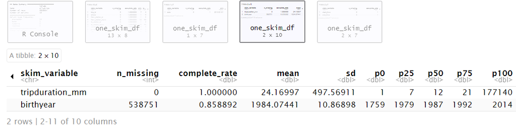

   p100 for tripduration_mm is way higher compared to p75, and birthyear ranges from 1759 to 2014, which makes the age of the rider from 5 to 260 in year 2019.

First, let’s inspect **tripduration_mm**.

There are 951 trips that lasted more than 2 days (2880 minutes).

```r
all_trips %>%
  filter(tripduration_mm >2880) %>%
  arrange(-tripduration_mm)
```

```
## # A tibble: 951 × 18
##    trip_id  start_time          end_time            bikeid tripduration_mm
##    <chr>    <dttm>              <dttm>              <chr>            <dbl>
##  1 21920842 2019-02-14 14:44:13 2019-06-17 16:04:35 3846            177140
##  2 23798837 2019-07-16 18:17:58 2019-10-29 14:01:52 1229            150944
##  3 25302386 2019-10-06 13:57:02 2020-01-13 21:55:24 6232            143098
##  4 23889502 2019-07-22 12:09:36 2019-10-25 10:56:54 773             136727
##  5 25487192 2019-10-19 15:14:50 2020-01-21 13:54:35 1083            135340
##  6 23710210 2019-07-12 13:08:10 2019-10-12 10:32:18 1219            132324
##  7 24107150 2019-08-01 18:45:47 2019-10-29 12:36:57 6061            127791
##  8 23661214 2019-07-10 10:25:13 2019-10-06 11:26:25 3102            126781
##  9 23648641 2019-07-09 17:28:05 2019-10-04 18:55:47 464             125368
## 10 23801970 2019-07-16 20:44:13 2019-10-10 18:01:25 6354            123677
## # ℹ 941 more rows
## # ℹ 13 more variables: from_station_id <chr>, from_station_name <chr>,
## #   to_station_id <chr>, to_station_name <chr>, usertype <chr>, gender <chr>,
## #   birthyear <dbl>, date <date>, year <chr>, month <chr>, day <chr>,
## #   day_of_week <chr>, time_of_day_hour <chr>
```

And 729 of them are casual users.

```r
all_trips %>%
  filter(tripduration_mm >2880 & usertype=="casual") %>%
  arrange(-tripduration_mm)
```

```
## # A tibble: 729 × 18
##    trip_id  start_time          end_time            bikeid tripduration_mm
##    <chr>    <dttm>              <dttm>              <chr>            <dbl>
##  1 21920842 2019-02-14 14:44:13 2019-06-17 16:04:35 3846            177140
##  2 25302386 2019-10-06 13:57:02 2020-01-13 21:55:24 6232            143098
##  3 25487192 2019-10-19 15:14:50 2020-01-21 13:54:35 1083            135340
##  4 23710210 2019-07-12 13:08:10 2019-10-12 10:32:18 1219            132324
##  5 24107150 2019-08-01 18:45:47 2019-10-29 12:36:57 6061            127791
##  6 23661214 2019-07-10 10:25:13 2019-10-06 11:26:25 3102            126781
##  7 23648641 2019-07-09 17:28:05 2019-10-04 18:55:47 464             125368
##  8 23801970 2019-07-16 20:44:13 2019-10-10 18:01:25 6354            123677
##  9 24194299 2019-08-05 17:13:20 2019-10-28 14:29:10 1677            120796
## 10 23723936 2019-07-12 22:44:18 2019-10-01 09:44:05 880             115860
## # ℹ 719 more rows
## # ℹ 13 more variables: from_station_id <chr>, from_station_name <chr>,
## #   to_station_id <chr>, to_station_name <chr>, usertype <chr>, gender <chr>,
## #   birthyear <dbl>, date <date>, year <chr>, month <chr>, day <chr>,
## #   day_of_week <chr>, time_of_day_hour <chr>
```

These rows are either bad data or there are actually many casual users who ended up returning bikes very late and had to pay a lot (often, weeks or months of daily passes prices). *If* these trips are by real riders, they are a group of customers the company should reach out to market annual membership option. Toward the end of this report, I will analyze this group.

For main analysis, however, *I will assume that these are bad data.* So, I’ll remove all the rows with **trip duration lasting more than 24 hours.**

But before that, let’s also check for trips that were too short.  
There are 61026 trips that lasted less than 3 minutes and starting station are not same as ending station. I will assume that a trip to one station to another takes at least 3 minutes. So, I will remove these rows.

```r
all_trips %>%
  filter(tripduration_mm <3 & from_station_id!=to_station_id) %>%
  arrange(tripduration_mm) %>%
  select(tripduration_mm, from_station_id, to_station_id, usertype)
```

```
## # A tibble: 61,026 × 4
##    tripduration_mm from_station_id to_station_id usertype
##              <dbl> <chr>           <chr>         <chr>
##  1               1 77              91            member
##  2               1 224             93            member
##  3               1 620             31            member
##  4               1 31              620           member
##  5               1 323             253           member
##  6               1 96              66            member
##  7               1 98              51            member
##  8               1 48              364           member
##  9               1 71              233           member
## 10               1 304             232           member
## # ℹ 61,016 more rows
```

There are also 10013 trips that lasted less than 3 minutes and starting station are same as ending stations. Even if someone returns a bike to the same station where he or she picked up from, it should take at least 3 minutes to ride somewhere and come back. So, I will also assume that these are not actual trips either.

```r
all_trips %>%
  filter(tripduration_mm <3 & from_station_id==to_station_id) %>%
  arrange(tripduration_mm) %>%
  select(tripduration_mm, from_station_id, to_station_id, usertype)
```

```
## # A tibble: 10,013 × 4
##    tripduration_mm from_station_id to_station_id usertype
##              <dbl> <chr>           <chr>         <chr>
##  1               1 59              59            member
##  2               1 115             115           member
##  3               1 129             129           member
##  4               1 97              97            casual
##  5               1 188             188           member
##  6               1 260             260           member
##  7               1 264             264           member
##  8               1 300             300           member
##  9               1 284             284           member
## 10               1 237             237           member
## # ℹ 10,003 more rows
```

Thus, if a trip lasted less than 3 minutes regardless of starting and ending station, I’ll assume that it is not a valid data from a real trip.

I’ve also discovered that there is one trip that was for a special event.  
I am removing that one trip, along with all the trips longer than 24 hours or shorter than 3 minutes.

```r
all_trips_cleaned <- subset(all_trips, tripduration_mm <=1440 & tripduration_mm >=3 & from_station_id!=1)
```

all_trips_filtered_cleaned_1 has 3745116 rows

As for bad data with birth year, I will clean them after I make a filtered version with age and gender information.

## 4. Filter data and some more Cleaning

Now I’ve finished basic cleaning, I will make two filtered version of all_trips.  
**all_trips_filtered_1** has trip ID, month, day of week, time of day, trip duration, from station ID, end station ID, and user type.

```r
all_trips_filtered_1 <- select(all_trips_cleaned, trip_id, month, day_of_week, time_of_day_hour, tripduration_mm, from_station_id, to_station_id, usertype)
```

**all_trips_filtered_2_age_gender** has all the columns of **all_trips_filtered_1** plus gender and birth year.

```r
all_trips_filtered_2_age_gender <- select(all_trips_cleaned, trip_id, month, day_of_week, time_of_day_hour, tripduration_mm, from_station_id, to_station_id, usertype, gender, birthyear)
```

As explained earlier, from **all_trips_filtered_2_age_gender** data frame, I still need to clean out the rows with **missing gender or birth year** and rows with **unlikely birth year.** I will assume that only rows with birth year within range from 1920 to 2009 (age 10 to 99 at the year 2019) are valid data.

```r
all_trips_filtered_2_age_gender <- all_trips_filtered_2_age_gender %>%
  na.omit(all_trips_filtered_2_age_gender) %>%
  subset(birthyear >= 1920 & birthyear <= 2009)
```

The **all_trips_filtered_2_age_gender** has now 3188381 rows.

## 5. Analysis and Visualization

This was an exciting stage where I could finally see what’s really going on with the data.

1. First of all, I wanted to see **some general statistics** for each type of user.

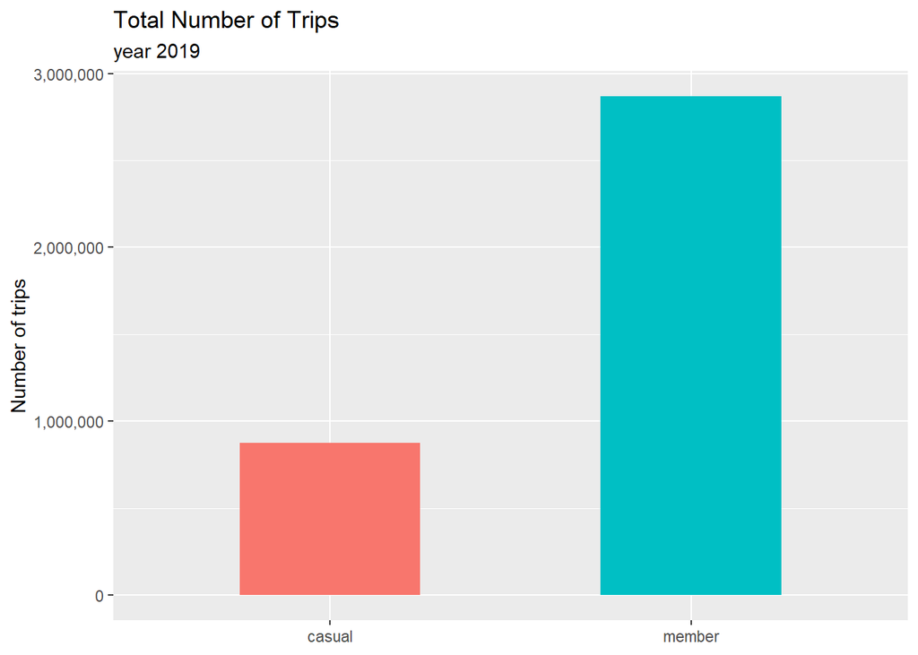

```r
ggplot(all_trips_filtered_1) +
  geom_bar(aes(x=usertype, fill=usertype), width=0.5, show.legend=FALSE) +
  labs(title="Total Number of Trips", subtitle="year 2019",
            x=NULL, y="Number of trips" )+
  scale_y_continuous(labels = comma)
```

As for total number of trips, annual members made three times more trips than casual riders.

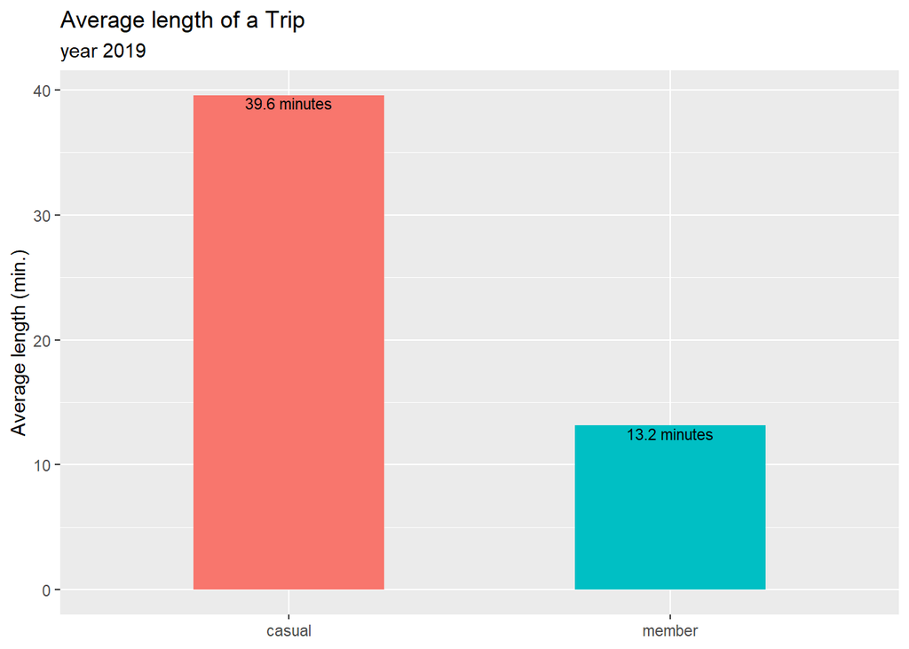

```r
all_trips_filtered_1 %>%
  group_by(usertype) %>%
  summarize(avg_tripduration = mean(tripduration_mm)) %>%
  ggplot() +
  geom_col(aes(x=usertype, y=avg_tripduration, fill=usertype), width=0.5, show.legend=FALSE)+
  labs(title="Average length of a Trip", subtitle="year 2019",
            x=NULL, y="Average length (min.)" )+
  scale_y_continuous(labels = comma)+
  annotate("text", x=1, y=39, label="39.6 minutes", size=3)+
  annotate("text", x=2, y=12.5, label="13.2 minutes", size=3)
```

As average length of trips, casual riders tend to make 3 times longer trips than annual members.  
This might be because casual riders use Cyclistic only when they ride for a longer time, whereas annual members tend to use it more frequently.

I tried to break down the number of rides and average length of trips by month, day of week, and time of day.

2. I wanted to see the usage pattern **by months**, to see if there is any seasonal difference. After all, biking is an outdoor activity, and not many people would enjoy biking in freezing weather.

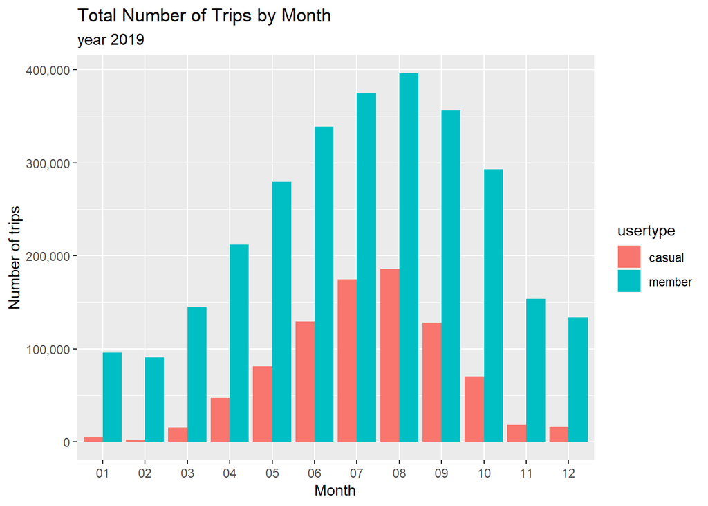

```r
ggplot(all_trips_filtered_1) +
  geom_bar(aes(x=month, fill=usertype), position="dodge") +
  ##facet_wrap(~usertype)+
  labs(title="Total Number of Trips by Month", subtitle="year 2019",
            x="Month", y="Number of trips" )+
  scale_y_continuous(labels = comma)
```

As expected, the chart shows that summertime (July and August) are the peak months for both members and casual riders.

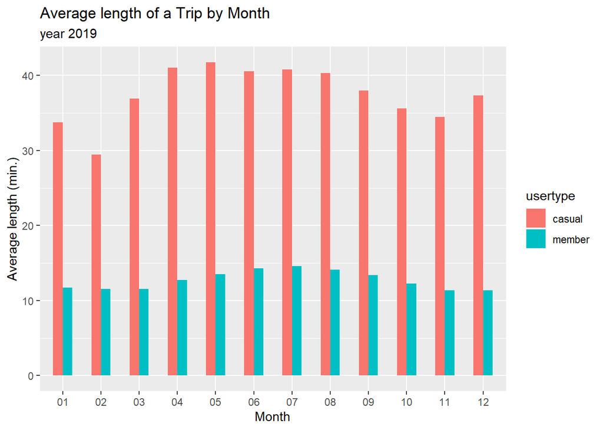

```r
all_trips_filtered_1 %>%
  group_by(usertype, month) %>%
  summarize(avg_tripduration = mean(tripduration_mm)) %>%
  ggplot() +
  geom_col(aes(x=month, y=avg_tripduration, fill=usertype), position="dodge", width=0.5)+
  labs(title="Average length of a Trip by Month", subtitle="year 2019",
            x="Month", y="Average length (min.)")+
  scale_y_continuous(labels = comma)
```

As for average length of trip, both types of riders tend to take slightly longer trips on warmer months than colder months. But casual riders seem to enjoy longer trips on warmer months more, whereas for annual members, the trip duration doesn’t vary as much.

3. Next, I examined the riding pattern **by day of week**.

But, First, I noticed that the days of the week are out of order, so I fixed this.

```r
all_trips_filtered_1$day_of_week <- ordered(all_trips_filtered_1$day_of_week, levels=c("Sun", "Mon", "Tue", "Wed", "Thu", "Fri", "Sat"))
```

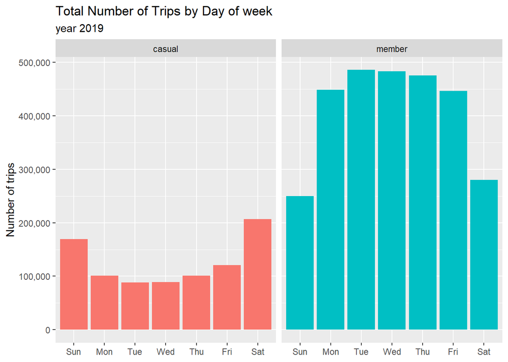

```r
ggplot(all_trips_filtered_1) +
  geom_bar(aes(x=day_of_week, fill=usertype), show.legend = FALSE) +
  labs(title="Total Number of Trips by Day of week", subtitle="year 2019",
            x=NULL, y="Number of trips" )+
  scale_y_continuous(labels = comma)+
  facet_wrap(~usertype)
```

Casual riders make more trips on weekends, whereas annual members make more trips on weekdays. One can probably guess that annual members use bicycles primarily for means of commute, while casual riders primarily ride for leisure.

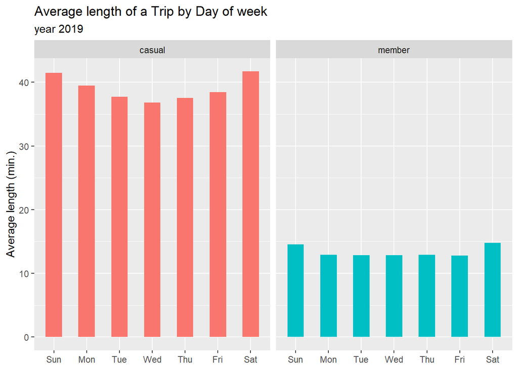

```r
all_trips_filtered_1 %>%
  group_by(usertype, day_of_week) %>%
  summarize(avg_tripduration = mean(tripduration_mm)) %>%
  ggplot() +
  geom_col(aes(x=day_of_week, y=avg_tripduration, fill=usertype), show.legend=FALSE, width=0.5)+
  labs(title="Average length of a Trip by Day of week", subtitle="year 2019",
            x=NULL, y="Average length (min.)")+
  scale_y_continuous(labels = comma)+
  facet_wrap(~usertype)
```

Casual users not only make more trips on weekends than weekdays, but they also make longer trips on weekends.  
Members make longer trips on weekends as well, but as we saw earlier, they just don’t make as many trips on weekends compared to weekdays.

4. Then, I examined the riding pattern **by the time of day**.

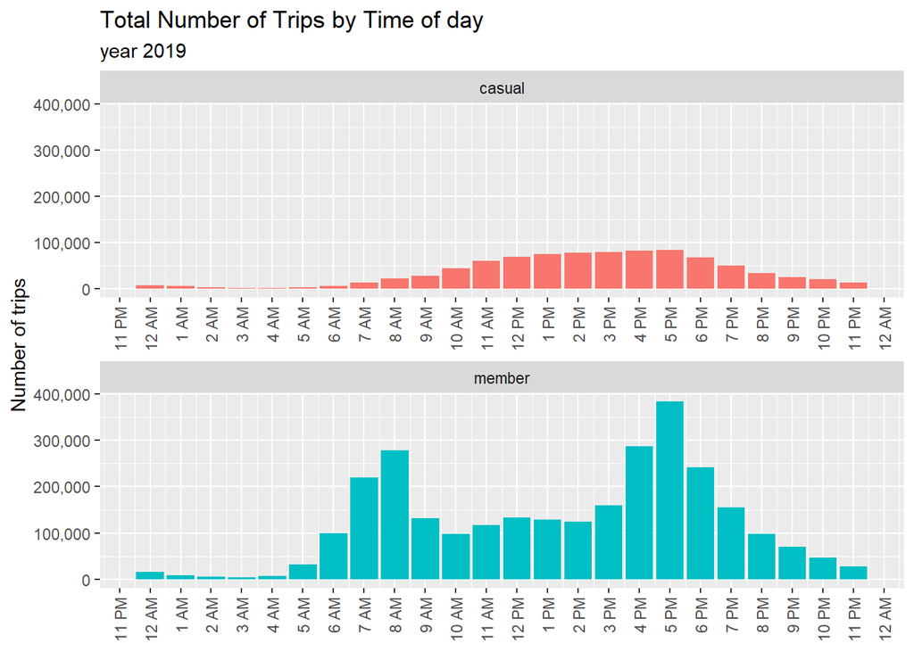

```r
all_trips_filtered_1 %>%
  mutate(hour=as.POSIXct(time_of_day_hour, format="%H")) %>%
  ggplot() + geom_bar(aes(x=hour, fill=usertype), show.legend = FALSE) +
  labs(title="Total Number of Trips by Time of day", subtitle="year 2019",
            x=NULL, y="Number of trips" )+
  scale_y_continuous(labels = comma)+
  facet_wrap(~usertype, nrow=2, scales="free_x")+
  scale_x_datetime(breaks=breaks_width("1 hour"), date_labels="%l %p")+
  theme(axis.text.x=element_text(angle=90, vjust=0.5, hjust=1) )
```

Now I am even **more sure that annual members are mainly using Cyclistic for commuting purpose**, as the chart above show peak times of trips (7~8AM and 5PM). As for casual riders, there’s no obvious peak, but it’s more common for them to ride between 11am to 6pm. Perhaps that’s just a nice time to ride for leisure?

This brought me an interesting question. **What’s keeping the casual riders from using bicycle for daily commute?** If they used a bicycle daily, that would give them enough reason to join the annual membership. But obviously something is keeping them from using bicycles for commute.

At this point, I felt that the main obstacle might be their need to transport their kids. All parents, including me, know it’s hard to ride a bicycle with little kids. As much as I would love to bike to work, I need to drop my kids off every morning and pick them up after work. This would make my bicycle-commuting impossible. So, maybe Cyclistic could provide kids friendly service such as kids bike seat options?

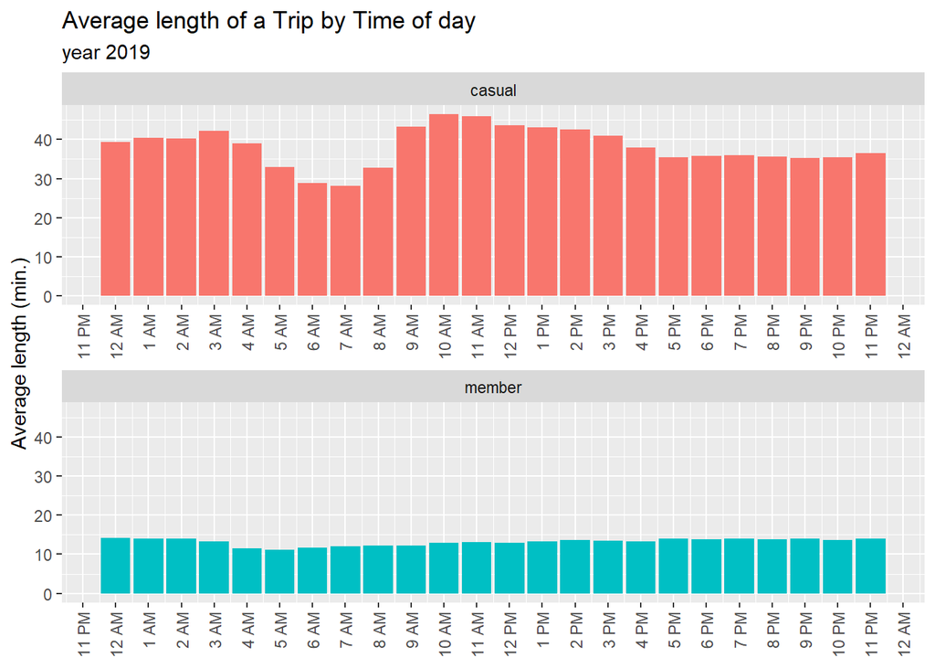

```r
all_trips_filtered_1 %>%
  mutate(hour=as.POSIXct(time_of_day_hour, format="%H")) %>%
  group_by(usertype, hour) %>%
  summarize(avg_tripduration = mean(tripduration_mm)) %>%
  ggplot() +
  geom_col(aes(x=hour, y=avg_tripduration, fill=usertype), show.legend=FALSE)+
  facet_wrap(~usertype, nrow=2, scales="free_x")+
  scale_x_datetime(breaks=breaks_width("1 hour"), date_labels="%l %p")+
  theme(axis.text.x=element_text(angle=90, vjust=0.5, hjust=1) )+
  labs(title="Average length of a Trip by Time of day", subtitle="year 2019",
            x=NULL, y="Average length (min.)")
```

The only thing I found interesting about this chart is that casual riders’ trips tend to be shorter on 5am to 8am compared to any other time of day.

5. After looking at the number of rides and average trip duration by month, day of week, and time of day, I moved my focus to age and gender. What is the **age and gender** composition of each type of riders?

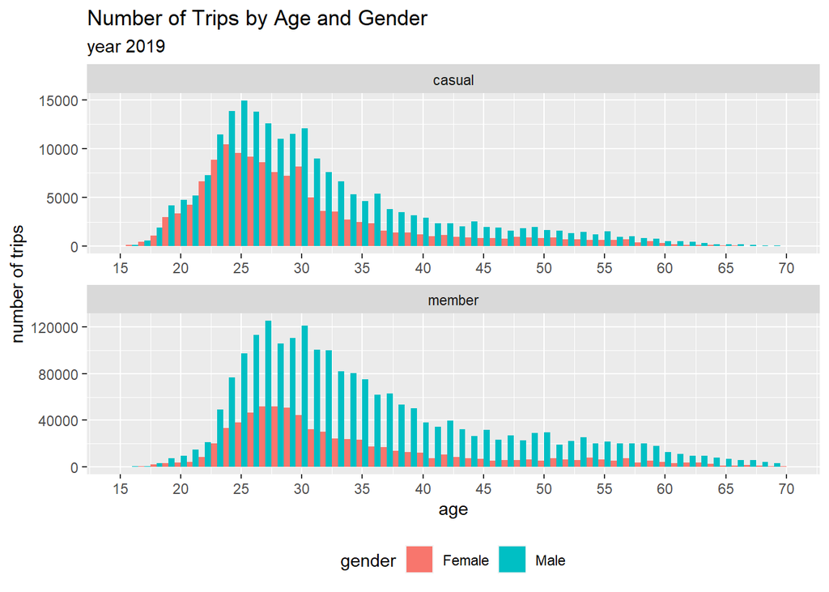

```r
all_trips_filtered_2_age_gender %>%
  mutate(age=2019-birthyear) %>%
  ggplot()+geom_bar(aes(x=age, fill=gender), position="dodge", width=1)+
  facet_wrap(~usertype, nrow=2, scales="free")+
  scale_x_continuous(breaks=breaks_width(5), limits=c(15,70))+
  theme(legend.position="bottom")+
  labs(title="Number of Trips by Age and Gender", subtitle="year 2019",
            x="age", y="number of trips")
```

For both types of riders, most of the riders are males in early 20s to mid-30s.  
However, the peak age for casual riders tends to be slightly younger than members. As for male, casual riders peak at age 23 to 30, whereas members peak at age 25 to 32. As for female, casual riders peak at age 22 to 30 whereas members peak at age 26 to 30. You can also see that the casual riders graph looks slightly heavier on the left side compared to the members.

This chart was a surprise to me, as I personally had imagined what’s keeping casual riders from biking to commute was their needs to travel with small kids. However, looking at the age composition of riders, I realized that I probably had been wrong. (Of course, I can’t just assume that people don’t have kids in early 20s to early 30s. To find out if kids are the major factor, we need more information.) **Maybe** (again, I don’t know for sure without more data), these casual riders in their early 20s to 30s are **more likely to be singles**, and there are other fun things to do than biking, so they just use it on weekend for leisure?

Because I know that casual ride tend to rider primarily on weekends, I wanted to focus more on the weekend riders. If we are to try to switch them to annual members, we need to first find out who they are.

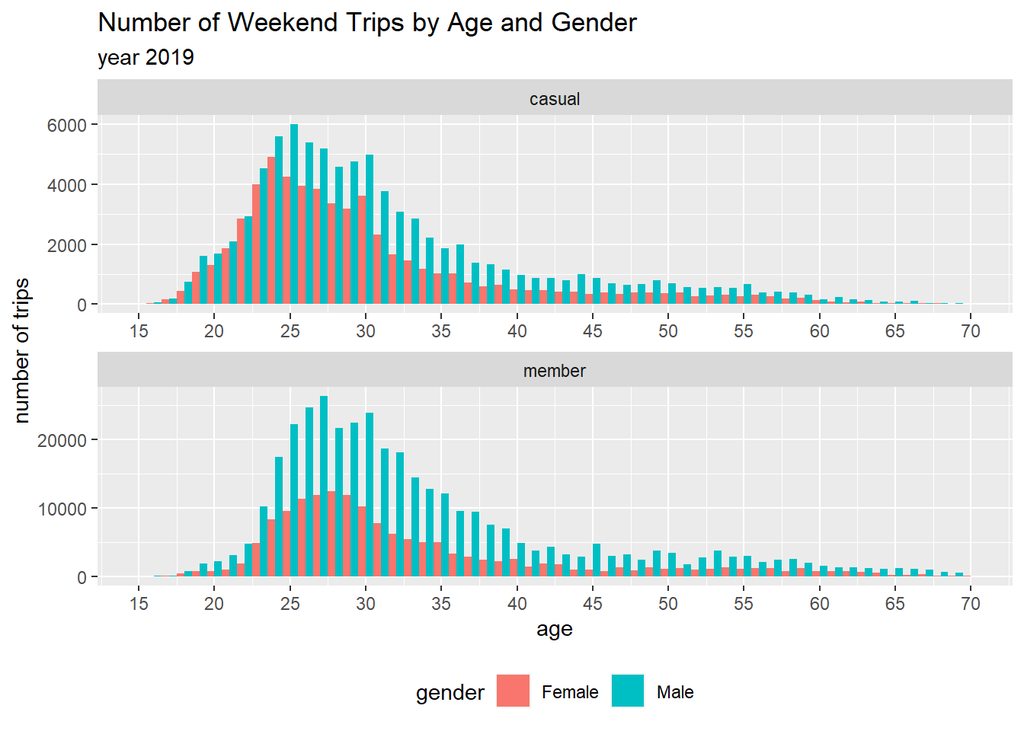

```r
all_trips_filtered_2_age_gender %>%
  filter(day_of_week=="Sat"|day_of_week=="Sun") %>%
  mutate(age=2019-birthyear) %>%
  ggplot()+geom_bar(aes(x=age, fill=gender), position="dodge", width=1)+
  facet_wrap(~usertype, nrow=2, scales="free")+
  scale_x_continuous(breaks=breaks_width(5), limits=c(15,70))+
  theme(legend.position="bottom")+
  labs(title="Number of Weekend Trips by Age and Gender", subtitle="year 2019",
            x="age", y="number of trips")
```

As we can see, demographic composition for weekend riders is not that much different from all riders. Still peaking at early 20s to early 30s and male-heavy, casual riders tends to be slightly younger than members.

6. Finally, I’ve analyzed the group of **casual riders who have taken longer than 24 hours** to return their bikes. (Remember that I’ve removed all the trips that lasted more than 24 hours and excluded them from the main analysis? But, in case these are valid data from real trips, it would be useful to learn more about these casual riders who made these very long “trips” and perhaps had to pay higher price than they had planned to.)

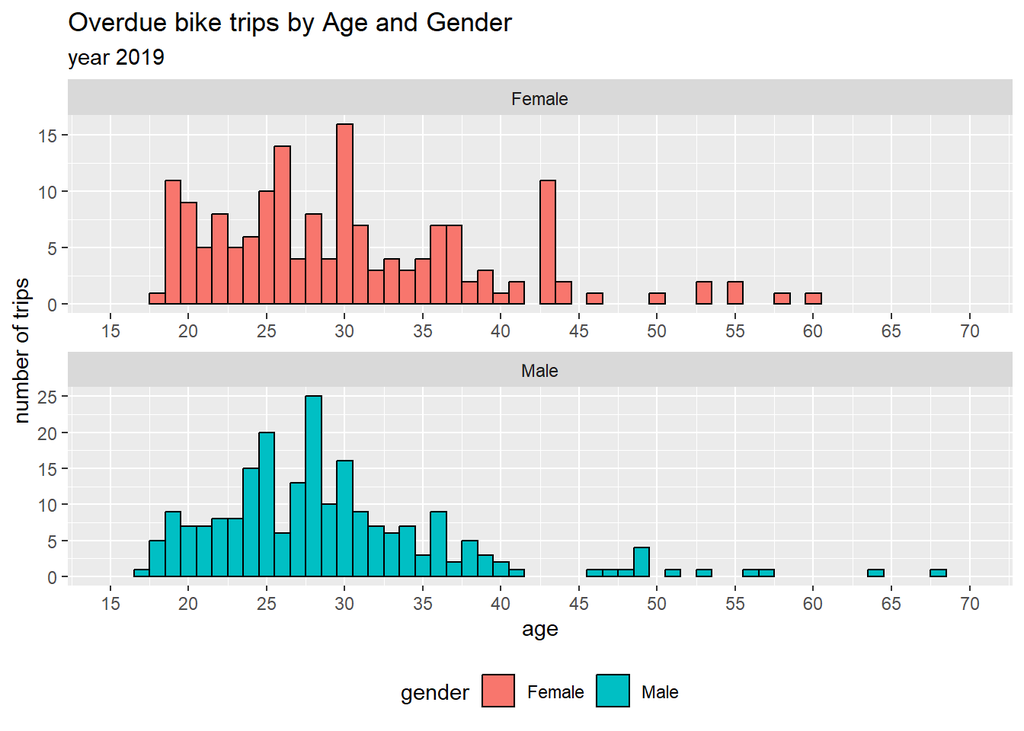

```r
all_trips %>%
  filter(tripduration_mm>1440 & usertype=="casual" & !is.na(gender)) %>%
  mutate(age=2019-birthyear) %>%
  ggplot()+geom_bar(aes(x=age, fill=gender), position="dodge", width=1, color="black")+
  facet_wrap(~gender, nrow=3, scales="free")+
  scale_x_continuous(breaks=breaks_width(5), limits=c(15,70))+
  theme(legend.position = "bottom")+
  labs(title="Overdue bike trips by Age and Gender", subtitle="year 2019",
            x="age", y="number of trips")
```

These are the casual riders who returned their bike more than 24 hours after the pickup. They probably had to pay for many days or weeks of daily bike passes. They are more likely in their 20s and 30s, as that’s the age group for most of riders any way.

I got curious of how many days they keep their bicycle before returning. Is there any relationship with age? (i.e., Are younger people tending to forget to return it longer?)

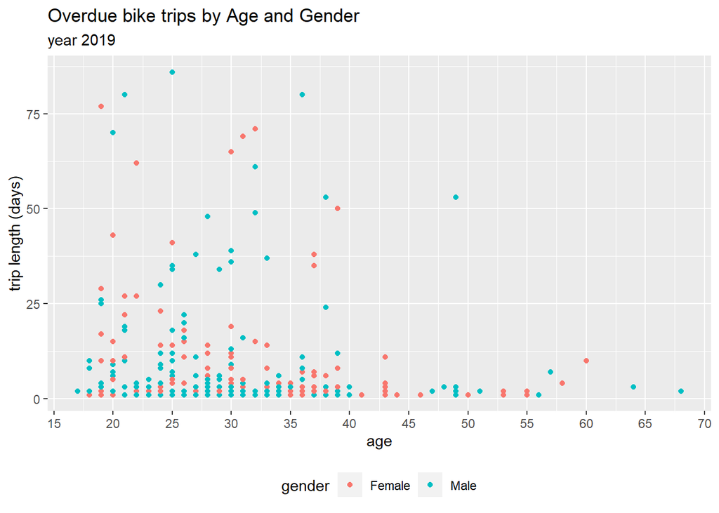

```r
all_trips %>%
  filter(tripduration_mm>1440 & usertype=="casual" & !is.na(gender)) %>%
  mutate(age = 2019-birthyear, tripduration_day = round(tripduration_mm/1440, digits=0)) %>%
  ggplot()+
  geom_point(aes(x=age, y=tripduration_day, color=gender), position="dodge", width=1)+
  scale_x_continuous(breaks=breaks_width(5))+
  theme(legend.position = "bottom")+
  labs(title="Overdue bike trips by Age and Gender", subtitle="year 2019",
            x="age", y="trip length (days)")
```

People in 20s and 30s tend to keep the bicycle longer than those in 40s or 50s.  
It was shocking that many riders don’t return their bike for so long, many even longer than a month! If they were annual members, they wouldn’t have to pay anything extra by forgetting to return the bike.

## 6. Some conclusions and reflections

As for the original business question of “how do casual riders and annual members use Cyclistics differently?”  
Here are some differences:

- Casual riders ride primarily on **weekends**, whereas members ride primarily on weekdays.
- Casual riders seem to ride more **for leisure**, whereas members ride primarily to commute to work.
- Casual riders tend to be slightly **younger** than members, although people in early 20s to 30s are the majority for both groups.

For both types of riders, there are **more males** than females and most of riders are people in **early 20s to early 30s**.

For the marketing team to further discuss the questions of **what could motivate casual riders to switch to annual membership** and **how social media could be used to influence casual riders to become members**, this data analysis can provide some insights.

- Considering most casual riders are in their early 20s to early 30s, Cyclistic could provide weekly or monthly events that people in this age group would enjoy. One example would be **an outdoor gathering event with live music and food, exclusively for the annual members.** This kind of event would provide some leisure and **socialization opportunities** for the young riders. Whether or not these riders start to use bikes for commuting, being able to join events to meet other bikers could make joining the membership worthwhile for them.
- Another event that Cyclistic can offer to members is **a bike trip on weekends.** Casual riders already enjoy biking on weekends. By providing organized bike trips, Cyclistic can provide them with more opportunities to meet new people and have **fun.**
- Another idea would be to reach out to a company where the majority of employees are in their 20s and 30s and seek out partnership. **Employees could get a discount for annual membership** as as part of the company’s employee benefit. This would give more reasons to join the annual membership.
- Assuming (this is a big assumption) that people in their 20s and 30s tend to be more passionate about **sustainability**, Cyclistic can donate a portion of its revenue from the annual membership fee to organizations to improve sustainability of the community. New members would feel proud that they are not only helping reducing Co2 emission but also helping donating for more sustainable community.  
  (As mentioned earlier, this is a big assumption. Finding out whether younger people tend to be more passionate about sustainability issue is a topic for a different investigation. But, I think this assumption can be true because younger people who don’t have family to take care of might have more time and energy do something to make a difference in a society.)
- When creating **adveretisement on Social media**, Cyclistic can try to incorporate what’s important to people in their 20s and 30s, such as **fun, socialization, sustainability, and convenience.** (Biking can be more convenient than driving a car, because for example, if a member biked to work and ended up having some cocktails with her friends after work, she doesn’t have to worry about her car. She could use the public transportation or Uber. If she drove to work in the morning, it would be headache: Think about overnight parking, needing a car in the morning for commute.)
- Cyclistic can also reach out **interest groups in social media**. There are various groups in social media for **sustainability, fitness, or social mingling.** It can organize **biking events** and offer **discount for joining membership.**
- Considering that the summer is the peak season for bike riders, Cyclistic can offer a **discount for membership fee during summer months.**
- Lastly, Cyclistic should reach out the **casual riders who have returned their bike later than 1 day** to discuss how they could save money by switching to annual members.